# Thư Viện NumPy Trong Python

**Numpy (Numeric Python)**: là một thư viện toán học phổ biến và mạnh mẽ của Python. Cho phép làm việc hiệu quả với ma trận và mảng, đặc biệt là dữ liệu ma trận và mảng lớn với tốc độ xử lý nhanh hơn nhiều lần khi chỉ sử dụng **core Python** đơn thuần.

### 1. Cài đặt thư viện Numpy

- Mở Command Prompt và gõ lệnh: **pip install numpy**

### 2. Các thao tác cơ bản

**Khai báo thư viện:**

```python
import numpy as np
```

**Khởi tạo mảng một chiều:**

```python
# Khởi tạo mảng một chiều với kiểu dữ liệu mặc định
arr = np.array([1,3,4,5,6])
print (arr)
```

```
[1 3 4 5 6]
```

```python
# Khởi tạo mảng một chiều với kiểu dữ liệu các phần tử là float
arr = np.array([1,3,4,5,6], dtype = float)
print (arr)
```

```
[1. 3. 4. 5. 6.]
```

**Khởi tạo mảng hai chiều:**

```python
arr2 = np.array([(4,5,6), (1,2,3)])
print(arr2)
```

```
[[4 5 6]
 [1 2 3]]
```

**Khởi tạo mảng ba chiều:**

```python
arr3 = np.array(([(2,4,0,6), (4,7,5,6)],
                 [(0,3,2,1), (9,4,5,6)],
                 [(5,8,6,4), (1,4,6,8)]))
print(arr3)
```

```
[[[2 4 0 6]
  [4 7 5 6]]

 [[0 3 2 1]
  [9 4 5 6]]

 [[5 8 6 4]
  [1 4 6 8]]]
```

**Khởi tạo với các hàm có sẵn:**

```python
# Tạo mảng hai chiều các phần tử 0 với kích thước 3x4:
arr_0 = np.zeros((3, 4), dtype = int)
print (arr_0)
```

```
[[0 0 0 0]
 [0 0 0 0]
 [0 0 0 0]]
```

```python
# Tạo mảng 3 chiều các phần tử 1 với kích thước 2 x 3 x 4:
arr_1 = np.ones((2, 3, 4), dtype = int)
print (arr_1)
```

```
[[[1 1 1 1]
  [1 1 1 1]
  [1 1 1 1]]

 [[1 1 1 1]
  [1 1 1 1]
  [1 1 1 1]]]
```

```python
# Tạo mảng với các phần tử từ 1 - 6 với bước nhảy là 2:
arr_16 = np.arange(1,7,2)
print (arr_16)
```

```
[1 3 5]
```

```python
# Tạo mảng 2 chiều các phần tử 5 với kích thước 2 x 3:
arr_5 = np.full((2,3),5)
print (arr_5)
```

```
[[5 5 5]
 [5 5 5]]
```

```python
# Tạo ma trận đơn vị với kích thước là 4 x 4:
arr44 = np.eye(4, dtype=int)
print (arr44)
```

```
[[1 0 0 0]
 [0 1 0 0]
 [0 0 1 0]
 [0 0 0 1]]
```

```python
# Tạo ma trận các phần tử ngẫu nhiên với kích thước 2 x 3:
arr23 = np.random.random((2,3))
print (arr23)
```

```
[[0.68890457 0.16593436 0.77862481]
 [0.69240302 0.08397561 0.70179535]]
```

### 3. Thao tác với mảng

- **dtype**: Kiểu dữ liệu của phần tử trong mảng.
- **shape**: Kích thước của mảng.
- **size**: Số phần tử trong mảng.
- **ndim**: Số chiều của mảng.

```python
# Kiểu dữ liệu của phần tử trong mảng:
arr.dtype
```

```
dtype('float64')
```

```python
# Kích thước của mảng:
arr3.shape
```

```
(3, 2, 4)
```

```python
# Số phần tử trong mảng:
arr_1.size
```

```
24
```

```python
# Số chiều của mảng:
arr_1.ndim
```

```
3
```

**Truy cập phần tử trong mảng:**

Các phần tử trong mảng được đánh số từ 0 trở đi

- **arr[ i ]**: Truy cập tới phần tử thứ i của mảng 1 chiều.
- **arr1[ i , j ]**: Truy cập tới phần tử hàng i, cột j của mảng 2 chiều.
- **arr2[ n, i, j ]**: Truy cập tới phần tử chiều n, hàng i, cột j của mảng 3 chiều.
- **arr[ a : b ]**: Truy cập tới các phần tử từ a đến b - 1 trong mảng 1 chiều.
- **arr1[ : , :i ]**: Truy cập tới phần tử từ cột 0 đến cột i - 1, của tất cả các hàng trong mảng 2 chiều.

```python
print("arr3[2,1,3] =", arr3[2,1,3])
```

```
arr3[2,1,3] = 8
```

**Các hàm thống kê:**

- **arr.max()** hoặc **np.max(arr)**: Lấy giá trị lớn nhất của mảng arr.
- **arr.min()** hoặc **np.min(arr)**: Lấy giá trị nhỏ nhất của mảng arr.
- **arr.sum()** hoặc **np.sum(arr)**: Tổng tất cả các phần tử trong mảng arr.
- **arr.mean()** hoặc **np.mean(arr)**: Trung bình cộng của tất cả các phần tử trong mảng arr.
- **np.median(arr)**: Trả về giá trị trung vị của mảng arr.

```python
# Giá trị lớn nhất của mảng arr3 là:
np.max(arr3)
```

```
9
```

```python
# Giá trị nhỏ nhất của mảng arr3 là:
np.min(arr3)
```

```
0
```

```python
# Tổng tất cả các phần tử của mảng arr3 là:
np.sum(arr3)
```

```
106
```

```python
# Trung bình cộng tất cả các phần tử của mảng arr3 là:"
np.mean(arr3)
```

```
4.416666666666667
```

```python
# Giá trị trung vị của mảng arr3 là:
np.median(arr3)
```

```
4.5
```

### 4. NumPy dtype

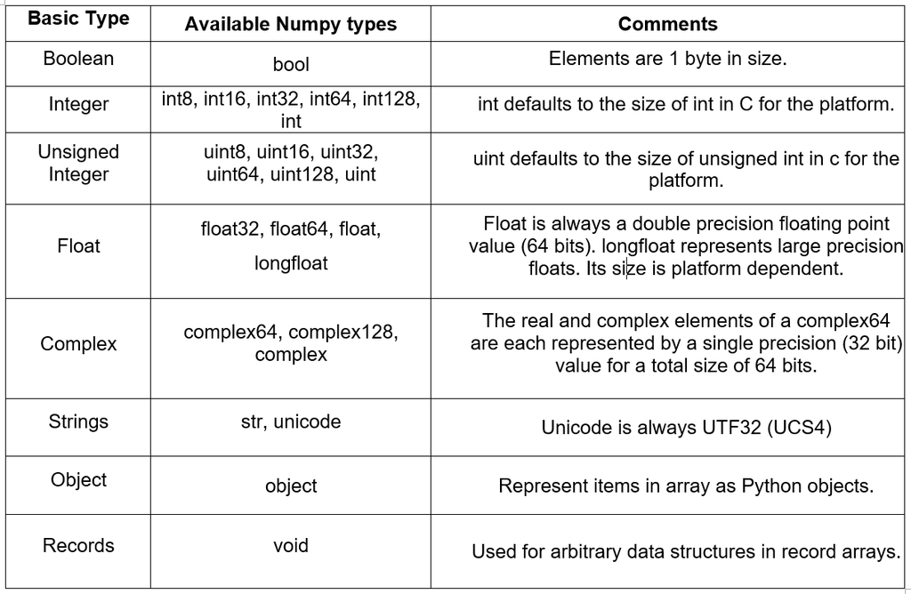

**Toán tử trong NumPy Array:**

```python
a = np.array([2, 1, 3, 4, 5])
```

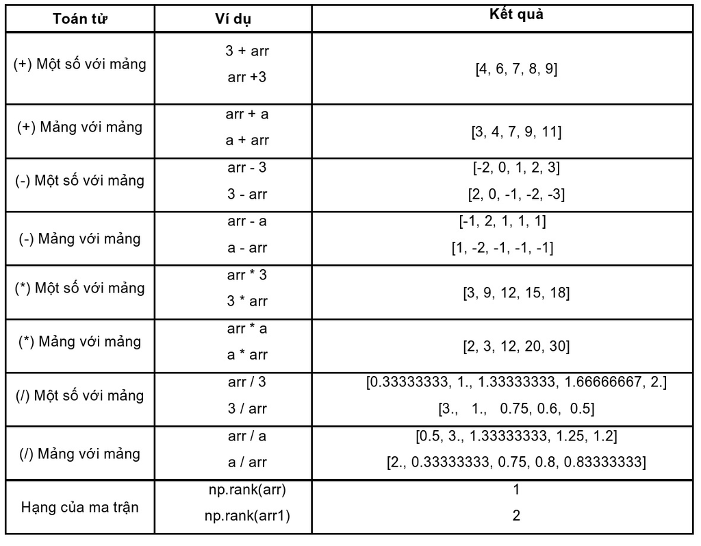